# Convolutional Neural Network (CNN): Cancer Detection

### Step 1: Description

**Problem Overview**

In this notebook we will create a binary classification algorithm using Convolutional Neural Networks to identify metastatic cancer in small image patches taken from larger digital pathology scans. The data we are using is a from the PCam dataset.

**Dataset Description**

In this dataset, you are provided with a large number of small pathology images to classify. Files are named with an image id. The train_labels.csv file provides the ground truth for the images in the train folder. You are predicting the labels for the images in the test folder. A positive label indicates that the center 32x32px region of a patch contains at least one pixel of tumor tissue. Tumor tissue in the outer region of the patch does not influence the label. This outer region is provided to enable fully-convolutional models that do not use zero-padding, to ensure consistent behavior when applied to a whole-slide image.

**Files:**

- train - folder with train images
- test - folder with test images
- train_labels.csv - ground truth for the images in the train folder
- sample_submission.csv - sample file for submission to kaggle competition

**Resources:**

- Kaggle: https://www.kaggle.com/c/histopathologic-cancer-detection/overview \
- Github: https://github.com/kpritch24/cnn-cancer-detection

```python
# import libraries
import os
import numpy as np
import pandas as pd
import tensorflow as tf
import matplotlib.pyplot as plt
import seaborn as sns
from glob import glob
import cv2
from sklearn.model_selection import train_test_split, ParameterGrid
from tensorflow.keras import layers, models
from tensorflow.keras.applications import EfficientNetV2B0

# plotting style
plt.style.use('default')
sns.set_theme()

# set variables
NUM_EPOCHS_TUNING = 2
NUM_EPOCHS_FINAL = 15
BATCH_SIZE_TUNING = 12000
BATCH_SIZE_FINAL = 2000
```

```python
def load_data():
    labels = pd.read_csv('./data/train_labels.csv')
    paths = glob(os.path.join('./data/train', '*.tif'))
    df = pd.DataFrame({'path': paths})
    df['id'] = df['path'].map(lambda p: os.path.splitext(os.path.basename(p))[0])
    return df.merge(labels, on='id')

df = load_data()
print(df.info())
```

```
<class 'pandas.core.frame.DataFrame'>
RangeIndex: 220025 entries, 0 to 220024
Data columns (total 3 columns):
 #   Column  Non-Null Count   Dtype
---  ------  --------------   -----
 0   path    220025 non-null  object
 1   id      220025 non-null  object
 2   label   220025 non-null  int64
dtypes: int64(1), object(2)
memory usage: 5.0+ MB
None
```

### Step 2: Exploratory Data Analysis (EDA)

First we start our exploratory data analysis by inspecting the class distribtuion and see there is a slight imbalance with roughly 60% negative examples vs 40% positive. We can also see there are no missing or duplicate examples in the dataset.

Next we sample some images in the dataset to compare cancer images vs normal images and can see there does appear to be visual differences in the image patches that can be used for training the deep learning model.

Since there are no missing or duplicate values, and all images are normalized and the same size, there is no further data cleaning necessary to prepare the dataset for model training.

Based on the EDA, the plan of analysis is to use a Convolutional Neural Network model and tune the hyperparameters to determine the best combination for use with training the final model. We will evaluate the model's performance using both accuracy and the area under the curve (AUC).

```
Class distribution:
 label
0    130908
1     89117
Name: count, dtype: int64
Missing values:
 path     0
id       0
label    0
dtype: int64
Duplicate rows: 0
```

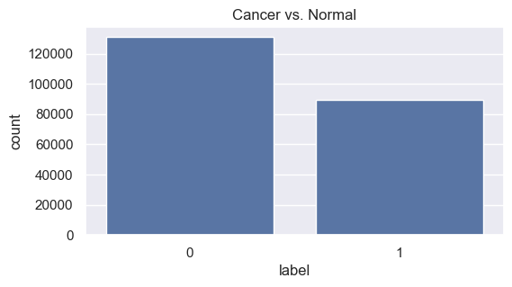

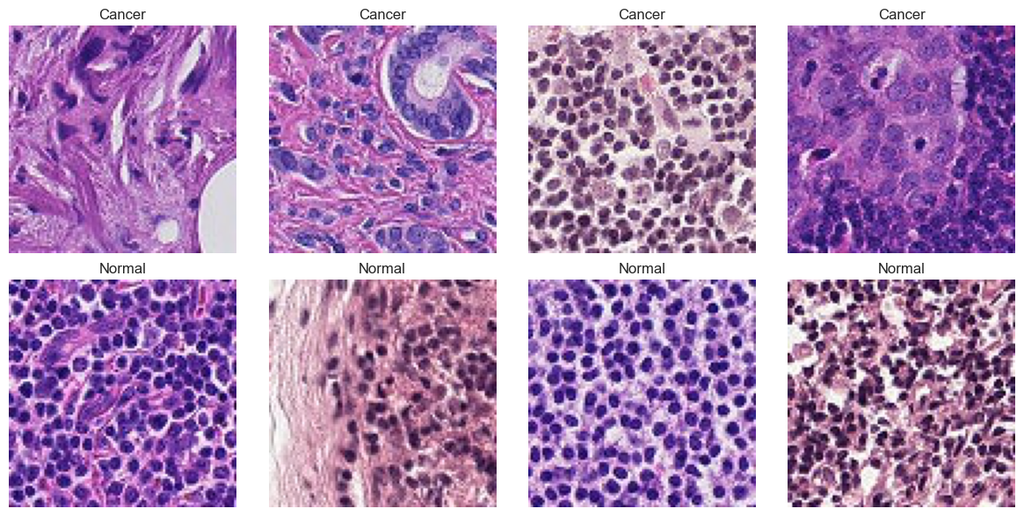

```python
# class distribution
print("Class distribution:\n", df['label'].value_counts())
print("Missing values:\n", df.isnull().sum())
print("Duplicate rows:", df.duplicated().sum())

plt.figure(figsize=(6,3))
sns.countplot(x='label', data=df)
plt.title('Cancer vs. Normal')
plt.show()

def load_and_preprocess_image(path):
    img = cv2.imread(path)
    img = cv2.cvtColor(img, cv2.COLOR_BGR2RGB)
    img = cv2.resize(img, (96,96))
    return img.astype(np.float32) / 255.0

def visualize_samples(df, n=8):
    pos = df[df.label==1].sample(n//2)
    neg = df[df.label==0].sample(n//2)
    samp = pd.concat([pos, neg]).reset_index(drop=True)
    plt.figure(figsize=(12,6))
    for i, row in samp.iterrows():
        img = load_and_preprocess_image(row.path)
        plt.subplot(2, n//2, i+1)
        plt.imshow(img)
        plt.title('Cancer' if row.label==1 else 'Normal')
        plt.axis('off')
    plt.tight_layout()
    plt.show()

visualize_samples(df)
```

### Step 3: Model Architecture

For the CNN architecture we will use the EfficientNetV2B0 algofirthm which is used for computer vision tasks and is known for both fast training and high accuracy. We will also use ParameterGrid to perform hyperparameter tuning to determine the optimal learning rate for convergence, as well as guarding against overfitting using the dropout rate. After we perform the hyperparamter tuning and evaluate the performance, we will use the best parameters found and train the final model with additonal epochs to produce the best performance of all our models.

```python
def create_model(learning_rate=1e-3, dropout_rate=0.5, dense_units=128, input_shape=(96,96,3)):
    base = EfficientNetV2B0(include_top=False, weights='imagenet', input_shape=input_shape)
    base.trainable = False
    inp = layers.Input(shape=input_shape)
    x = base(inp)
    x = layers.GlobalAveragePooling2D()(x)
    x = layers.Dense(dense_units, activation='relu')(x)
    x = layers.BatchNormalization()(x)
    x = layers.Dropout(dropout_rate)(x)
    x = layers.Dense(dense_units, activation='relu')(x)
    x = layers.BatchNormalization()(x)
    x = layers.Dropout(dropout_rate)(x)
    out = layers.Dense(1, activation='sigmoid')(x)
    model = models.Model(inp, out)
    model.compile(
        optimizer=tf.keras.optimizers.Adam(learning_rate),
        loss='binary_crossentropy',
        metrics=['accuracy', tf.keras.metrics.AUC(name='auc')]
    )
    return model
```

Here we create a function to prepare the images in the dataset using the cv2 library and then split the examples into training and validation sets using an 80/20 split as well as a batch size parameter for memory management when training the model.

```python
def prepare_dataset(df, batch_size=32, augment=True, shuffle=True):
    def _load(p, lbl):
        path = p.numpy().decode()
        img = cv2.imread(path)
        img = cv2.cvtColor(img, cv2.COLOR_BGR2RGB)
        img = cv2.resize(img, (96,96)) / 255.0
        return img.astype(np.float32), lbl
    def _wrap(p, lbl):
        img, lbl = tf.py_function(_load, [p, lbl], [tf.float32, tf.int64])
        img.set_shape((96,96,3)); lbl.set_shape(())
        return img, lbl

    ds = tf.data.Dataset.from_tensor_slices((df.path.values, df.label.values))
    ds = ds.map(_wrap, num_parallel_calls=tf.data.AUTOTUNE)
    if augment:
        ds = ds.map(lambda x,y: (tf.image.random_flip_left_right(x), y),
                    num_parallel_calls=tf.data.AUTOTUNE)
    if shuffle:
        ds = ds.shuffle(1000)
    return ds.batch(batch_size).prefetch(tf.data.AUTOTUNE)

# Split
train_df, val_df = train_test_split(df, test_size=0.2,
                                    stratify=df.label, random_state=42)
train_ds = prepare_dataset(train_df, batch_size=BATCH_SIZE_TUNING, augment=True, shuffle=True)
val_ds   = prepare_dataset(val_df, batch_size=BATCH_SIZE_TUNING, augment=False, shuffle=False)
```

# Step 4: Results and Analysis

Here we can see the results of the hyperparamter tuning which show that the best model used a learning rate of 1e-3 and dropout rate 0.5 which produced an accuracy of 0.59 and AUC 0.60, which we expect to see increase once we train the final model below with additional epochs. We can also wee that the higher dropout rate of 0.5 improved AUC compared to the dropout rate of 0.3. We can also see the bigger learning rate outperformed the lower learning rate.

```python
# hyperparamteter tuning
param_grid = {
    'learning_rate': [1e-3, 1e-4],
    'dropout_rate':  [0.3, 0.5],
    'dense_units':   [64]
}
results = []
for p in ParameterGrid(param_grid):
    m = create_model(
        learning_rate=p['learning_rate'],
        dropout_rate=p['dropout_rate'],
        dense_units=p['dense_units']
    )
    hist = m.fit(
        train_ds, validation_data=val_ds,
        epochs=NUM_EPOCHS_TUNING,
        callbacks=[tf.keras.callbacks.EarlyStopping(
            monitor='val_auc', patience=2, restore_best_weights=True)]
    )
    print(f"Model: lr={p['learning_rate']}, drop={p['dropout_rate']}, units={p['dense_units']}, val_auc={max(hist.history['val_auc'])}, val_acc={max(hist.history['val_accuracy'])}")
    results.append({
        **p,
        'val_accuracy': max(hist.history['val_accuracy']),
        'val_auc':      max(hist.history['val_auc'])
    })

results_df = pd.DataFrame(results)
print("Tuning results:\n", results_df)
```

```
15/15 ━━━━━━━━━━━━━━━━━━━━ 1089s 75s/step - accuracy: 0.5112 - auc: 0.5118 - loss: 0.8582 - val_accuracy: 0.5950 - val_auc: 0.5842 - val_loss: 0.6837
15/15 ━━━━━━━━━━━━━━━━━━━━ 246s 13s/step - accuracy: 0.5371 - auc: 0.5322 - loss: 0.7655 - val_accuracy: 0.4901 - val_auc: 0.5859 - val_loss: 0.6937
Model: lr=0.001, drop=0.3, units=64, val_auc=0.5859110355377197, val_acc=0.594977855682373
15/15 ━━━━━━━━━━━━━━━━━━━━ 199s 13s/step - accuracy: 0.4905 - auc: 0.4956 - loss: 0.9498 - val_accuracy: 0.5950 - val_auc: 0.5336 - val_loss: 0.6744
15/15 ━━━━━━━━━━━━━━━━━━━━ 188s 13s/step - accuracy: 0.5041 - auc: 0.5109 - loss: 0.8585 - val_accuracy: 0.5950 - val_auc: 0.5503 - val_loss: 0.6751
Model: lr=0.0001, drop=0.3, units=64, val_auc=0.5502656102180481, val_acc=0.594977855682373
15/15 ━━━━━━━━━━━━━━━━━━━━ 195s 13s/step - accuracy: 0.5087 - auc: 0.5074 - loss: 0.9365 - val_accuracy: 0.4089 - val_auc: 0.6049 - val_loss: 0.6965
15/15 ━━━━━━━━━━━━━━━━━━━━ 228s 15s/step - accuracy: 0.5233 - auc: 0.5136 - loss: 0.8410 - val_accuracy: 0.5950 - val_auc: 0.5679 - val_loss: 0.6851
Model: lr=0.001, drop=0.5, units=64, val_auc=0.6049197316169739, val_acc=0.594977855682373
15/15 ━━━━━━━━━━━━━━━━━━━━ 268s 18s/step - accuracy: 0.5069 - auc: 0.5070 - loss: 0.9338 - val_accuracy: 0.4050 - val_auc: 0.5016 - val_loss: 0.7068
15/15 ━━━━━━━━━━━━━━━━━━━━ 256s 17s/step - accuracy: 0.5121 - auc: 0.5136 - loss: 0.8960 - val_accuracy: 0.4050 - val_auc: 0.5707 - val_loss: 0.7147
Model: lr=0.0001, drop=0.5, units=64, val_auc=0.5707342028617859, val_acc=0.40502214431762695
Tuning results:
    dense_units  dropout_rate  learning_rate  val_accuracy   val_auc
0           64           0.3         0.0010      0.594978  0.585911
1           64           0.3         0.0001      0.594978  0.550266
2           64           0.5         0.0010      0.594978  0.604920
3           64           0.5         0.0001      0.405022  0.570734
```

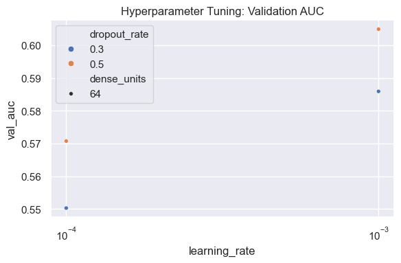

```python
# hypermarameter tuning results
plt.figure(figsize=(6,4))
sns.scatterplot(
    data=results_df, x='learning_rate', y='val_auc',
    hue='dropout_rate', size='dense_units', palette='deep'
)
plt.xscale('log')
plt.title('Hyperparameter Tuning: Validation AUC')
plt.tight_layout()
plt.show()
```

Next we training the final model using the best hyperparameters using the final number of epochs and batch size variables. We will use 15 epochs to give the model enough time to learn the patterns in the images and achieve the best possible performance.

```python
# final training with best hyperparameters
best = results_df.sort_values('val_auc', ascending=False).iloc[0]
best_lr  = float(best['learning_rate'])
best_dr  = float(best['dropout_rate'])
best_du  = int(best['dense_units'])
print("Best params:", best.to_dict())

train_ds = prepare_dataset(train_df, batch_size=BATCH_SIZE_FINAL, augment=True, shuffle=True)
val_ds   = prepare_dataset(val_df, batch_size=BATCH_SIZE_FINAL, augment=False, shuffle=False)

final_model = create_model(
    learning_rate = best_lr,
    dropout_rate  = best_dr,
    dense_units   = best_du
)
final_hist = final_model.fit(
    train_ds, validation_data=val_ds,
    epochs=NUM_EPOCHS_FINAL, verbose=1,
    callbacks=[tf.keras.callbacks.EarlyStopping(
        monitor='val_auc', patience=3, restore_best_weights=True)]
)
```

```
Best params: {'dense_units': 64.0, 'dropout_rate': 0.5, 'learning_rate': 0.001, 'val_accuracy': 0.594977855682373, 'val_auc': 0.6049197316169739}
89/89 ━━━━━━━━━━━━━━━━━━━━ 253s 3s/step - accuracy: 0.5181 - auc: 0.5191 - loss: 0.8632 - val_accuracy: 0.5950 - val_auc: 0.4508 - val_loss: 0.6765
89/89 ━━━━━━━━━━━━━━━━━━━━ 253s 3s/step - accuracy: 0.5648 - auc: 0.5592 - loss: 0.7184 - val_accuracy: 0.5950 - val_auc: 0.5898 - val_loss: 0.6722
89/89 ━━━━━━━━━━━━━━━━━━━━ 247s 3s/step - accuracy: 0.5818 - auc: 0.5822 - loss: 0.6821 - val_accuracy: 0.6257 - val_auc: 0.7028 - val_loss: 0.6831
89/89 ━━━━━━━━━━━━━━━━━━━━ 247s 3s/step - accuracy: 0.5953 - auc: 0.6079 - loss: 0.6617 - val_accuracy: 0.5950 - val_auc: 0.6777 - val_loss: 0.6508
89/89 ━━━━━━━━━━━━━━━━━━━━ 247s 3s/step - accuracy: 0.6070 - auc: 0.6217 - loss: 0.6559 - val_accuracy: 0.5950 - val_auc: 0.5419 - val_loss: 0.7266
89/89 ━━━━━━━━━━━━━━━━━━━━ 248s 3s/step - accuracy: 0.6208 - auc: 0.6485 - loss: 0.6416 - val_accuracy: 0.5950 - val_auc: 0.4989 - val_loss: 0.8683
```

# Step 5: Conclusion

Here we can see the results from the final model training and the accuracy and AUC over time as the number of epochs increased. The accuracy and AUC of the training set continues to increase as the accuracy and AUC of the validation set decreases, which indicates the model is still overfitting.

In the future, we could improve this model by evaluating additional hyperparameters or additional architectures such as label smoothing or ensemble methods. We could also experiment with the number of epochs used for training as well as the size of the batches.

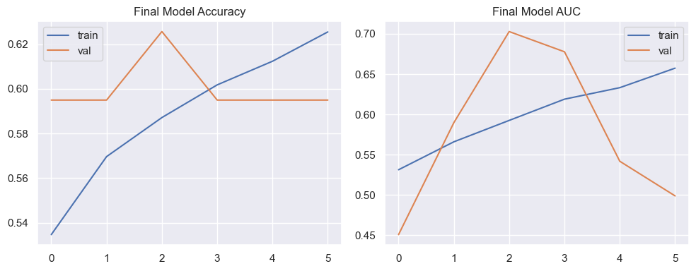

```
Final val_acc: 0.6256561875343323
Final val_auc: 0.7028473615646362
```

```python
# final results visualization
def plot_history(h, title):
    plt.figure(figsize=(10,4))
    plt.subplot(1,2,1)
    plt.plot(h.history['accuracy'], label='train')
    plt.plot(h.history['val_accuracy'], label='val')
    plt.title(f'{title} Accuracy'); plt.legend()
    plt.subplot(1,2,2)
    plt.plot(h.history['auc'], label='train')
    plt.plot(h.history['val_auc'], label='val')
    plt.title(f'{title} AUC'); plt.legend()
    plt.tight_layout(); plt.show()

plot_history(final_hist, 'Final Model')

print("Final val_acc:", max(final_hist.history['val_accuracy']))
print("Final val_auc:", max(final_hist.history['val_auc']))
```

```python
# Predict on Test & Prepare Kaggle Submission
test_paths = glob(os.path.join('./data/test', '*.tif'))
test_ids   = [os.path.splitext(os.path.basename(p))[0] for p in test_paths]
test_df    = pd.DataFrame({'id': test_ids, 'path': test_paths})

def prepare_test_dataset(df, batch_size=32):
    def _load(p):
        path = p.numpy().decode()
        img = cv2.imread(path)
        img = cv2.cvtColor(img, cv2.COLOR_BGR2RGB)
        img = cv2.resize(img, (96,96)) / 255.0
        return img.astype(np.float32)
    def _wrap(p):
        img = tf.py_function(_load, [p], tf.float32)
        img.set_shape((96,96,3))
        return img

    ds = tf.data.Dataset.from_tensor_slices(df['path'].values)
    ds = ds.map(_wrap, num_parallel_calls=tf.data.AUTOTUNE)
    return ds.batch(batch_size).prefetch(tf.data.AUTOTUNE)

test_ds = prepare_test_dataset(test_df)
preds   = final_model.predict(test_ds)

submission = pd.DataFrame({
    'id':    test_df['id'],
    'label': preds.ravel()
})
submission.to_csv('submission.csv', index=False)
print("Saved submission.csv")
```

```
1796/1796 ━━━━━━━━━━━━━━━━━━━━ 80s 44ms/step
Saved submission.csv
```

Lastly, we test the model using the test images and create a submission file containing our binary classifcation predictions for each of the test images. We then submit this to kaggle for grading in the competition.